# **Proyecto Final: Predicción del Riesgo de Enfermedades Cardíacas mediante Regresión Logística**

Autores:** Jesus David Arevalo, Juan Sebastian Quintana

# **Introducción:**

## **Contextualización:**

Las enfermedades cardíacas figuran entre las afecciones crónicas más prevalentes en los Estados Unidos, afectando a millones de estadounidenses cada año, con implicaciones significativas tanto para la salud individual como para la economía nacional. En los Estados Unidos, estas enfermedades cardiacas se sitúan como una de las principales causas de muerte, con aproximadamente 647,000 personas falleciendo por estas afecciones anualmente. La compleja interacción entre variables como el envejecimiento, la hipertensión y la diabetes contribuye como factores de riesgo y causas de enfermedades cardíacas.

## **Contenido:**

El Sistema de Vigilancia de Factores de Riesgo Conductuales (BRFSS, por sus siglas en inglés) es una encuesta telefónica sobre la salud que se recopila anualmente por los Centros para el Control y la Prevención de Enfermedades (CDC). Cada año, la encuesta recopila respuestas de más de 400,000 estadounidenses sobre comportamientos relacionados con la salud, condiciones de salud crónicas y el uso de servicios preventivos. Esta encuesta se realiza anualmente desde 1984. Para este proyecto, descargué un archivo CSV del conjunto de datos disponible en Kaggle correspondiente al año 2015. Este conjunto de datos original contiene respuestas de 441,455 individuos y comprende 330 características. Estas características incluyen preguntas directamente formuladas a los participantes o variables calculadas basadas en las respuestas individuales de los participantes.

Este conjunto de datos depurado contiene 253,680 respuestas de la encuesta BRFSS 2015, utilizado principalmente para la clasificación binaria de enfermedades cardíacas. Es relevante señalar que existe un fuerte desequilibrio de clases en este conjunto de datos: 229,787 encuestados no tienen o no han tenido enfermedad cardíaca, mientras que 23,893 han tenido enfermedad cardíaca.

## **Variables de estudio:**

```
##  [1] "HeartDiseaseorAttack" "HighBP"               "HighChol"
##  [4] "BMI"                  "Smoker"               "Stroke"
##  [7] "Diabetes"             "PhysActivity"         "Fruits"
## [10] "Veggies"              "HvyAlcoholConsump"    "Sex"
## [13] "Age"                  "Education"            "Income"
```

Se estudiarán diversas variables relacionadas con enfermedades cardíacas en el contexto de un modelo de regresión logística. Estas variables incluyen la presión arterial alta (**HighBP**), el colesterol alto (**HighChol**), el índice de masa corporal (**BMI**), el cual es calculado de foirma imperial es decir haciendo uso de unidades como *lb* y *inches*, el hábito de fumar (**Smoker**), la ocurrencia de accidentes cerebrovasculares (**Stroke**), el tipo de diabetes (**Diabetes**), la actividad física (**PhysActivity**), el consumo de frutas (**Fruits**), el consumo de verduras (**Veggies**) y el consumo intenso de alcohol (**HvyAlcoholConsump**). Además, se explorarán factores socioeconómicos como la educación (**Education**) y la categoria con respecto a los ingresos del encuestado (**Income**), junto con variables demográficas como el género (**Sex**) y la edad (**Age**) que esta encapsulada en 13 grupos donde los intervalos van de la siguiente manera:

Grupo1: 18≤edad<24, Grupo2: 24≤edad<30, Grupo3: 30≤edad<36 Grupo4: 36≤edad<43, Grupo5: 43≤edad<49,Grupo6: 49≤edad<55 Grupo7: 55≤edad<62, Grupo8: 62≤edad<68, Grupo9: 68≤edad<74 Grupo10: 74≤edad<81, Grupo11: 81≤edad<87, Grupo12: 87≤edad<93 Grupo13: 93≤edad<100,

Estos grupos fueron calculados de la siguiente manera:
$$\begin{align*}
& Rango = 100 - 18 = 82 \\
& Ancho = \frac{82}{13}\approx6.31
\end{align*}$$

## **Relevancia del trabajo:**

Este trabajo reconoce el impacto que esta enfermedad tiene en la tasa de mortalidad de los habitantes de los Estados Unidos y, más allá, el peso financiero generado. A partir de esto, surge la iniciativa de desarrollar diversas estrategias de prevención efectivas y precisas. El hecho de que las personas tiendan a descubrir que padecen alguna enfermedad cardíaca después de experimentar los primeros síntomas o, en casos extremos, después de un episodio que requirió intervención médica, como un paro cardíaco, respalda la urgencia de implementar medidas de intervención proactivas para evitar los desenlaces más graves. **Esto construirá una cultura de cuidado y prevención en torno a esta enfermedad, desde el profesional de la salud hasta el individuo.**

Identificar los factores de riesgo es fundamental para los Centros de Control y Prevención. De manera alarmante, aproximadamente la mitad de los estadounidenses presenta al menos uno de estos factores de riesgo. El Instituto Nacional del Corazón, Pulmón y Sangre destaca una gama más amplia de consideraciones diagnósticas, que abarcan la edad, el entorno, antecedentes familiares, genética, hábitos de vida, otras condiciones médicas, raza o etnia, y género. Estos factores constituyen la base para encuestas iniciales y pruebas diagnósticas posteriores.

El diagnóstico de una enfermedad cardíaca debe tener un enfoque integral, no basarse solo en las causas tradicionales, sino también considerar el panorama de la salud individual. Por lo tanto, herramientas como encuestas y pruebas diagnósticas, acompañadas de muestras de sangre, amplían la detección de factores de riesgo a un nivel más único para cada paciente, permitiendo una gestión efectiva de la enfermedad.

Abordar esta problemática desde el enfoque de la prevención es altamente relevante, como se ha observado en los párrafos anteriores. Además de la carga emocional y física para los individuos afectados, también representa un enorme desafío económico para el sistema de atención médica y para la sociedad en general. El costo asociado con el tratamiento de enfermedades cardíacas, incluyendo hospitalizaciones, procedimientos médicos y medicamentos, contribuye significativamente a los gastos totales en salud. La importancia de la prevención radica en la capacidad de mitigar estos costos, mejorar la calidad de vida de los individuos y, lo más crucial, salvar vidas. **Las estrategias preventivas pueden abordar no solo los factores de riesgo conocidos, sino también educar y empoderar a la población para tomar decisiones saludables en su vida diaria.**

## **Objetivos:**

En este trabajo, el objetivo principal es predecir de manera asertiva y eficiente el riesgo que una persona tiene de padecer una enfermedad cardíaca. También se tiene en cuenta la relación entre las variables actuales del conjunto de datos extraído, con el fin de explicar y entender los resultados a nivel predictivo. Es importante considerar que puede haber variables igualmente relevantes que no fueron incluidas en esta encuesta, de la cual se tomaron los datos.

# **Dataset:**

```
## # A tibble: 5 × 15
##   HeartDiseaseorAttack HighBP HighChol   BMI Smoker Stroke Diabetes PhysActivity
##   <fct>                <fct>  <fct>    <dbl> <fct>  <fct>  <fct>    <fct>
## 1 0                    1      1           40 1      0      0        0
## 2 0                    0      0           25 1      0      0        1
## 3 0                    1      1           28 0      0      0        0
## 4 0                    1      0           27 0      0      0        1
## 5 0                    1      1           24 0      0      0        1
## # ℹ 7 more variables: Fruits <fct>, Veggies <fct>, HvyAlcoholConsump <fct>,
## #   Sex <fct>, Age <fct>, Education <fct>, Income <fct>
```

# **Caracterizacion de la poblacion de estudio:**

## **Distribucion por sexo y edad:**

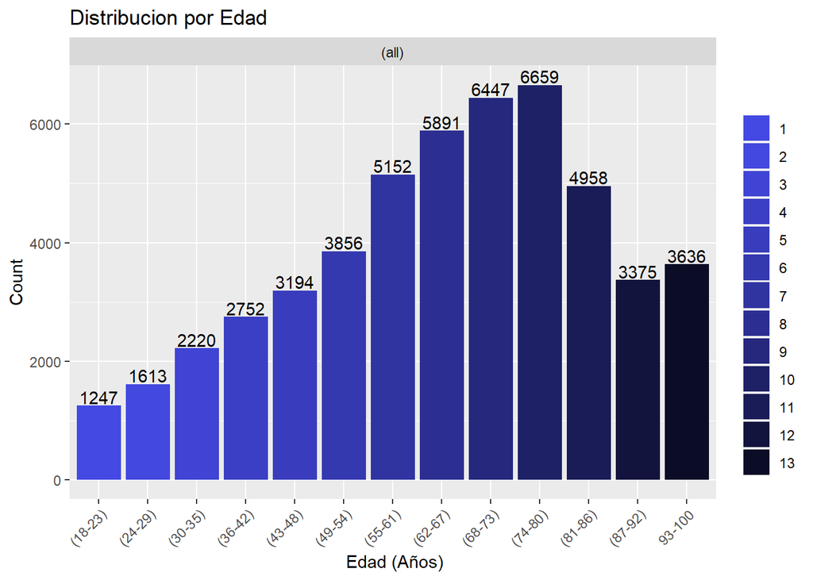

[figure not shown]

## **Distribucion por eduacion e ingresos:**

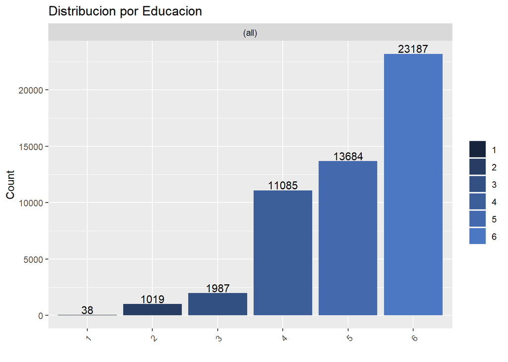

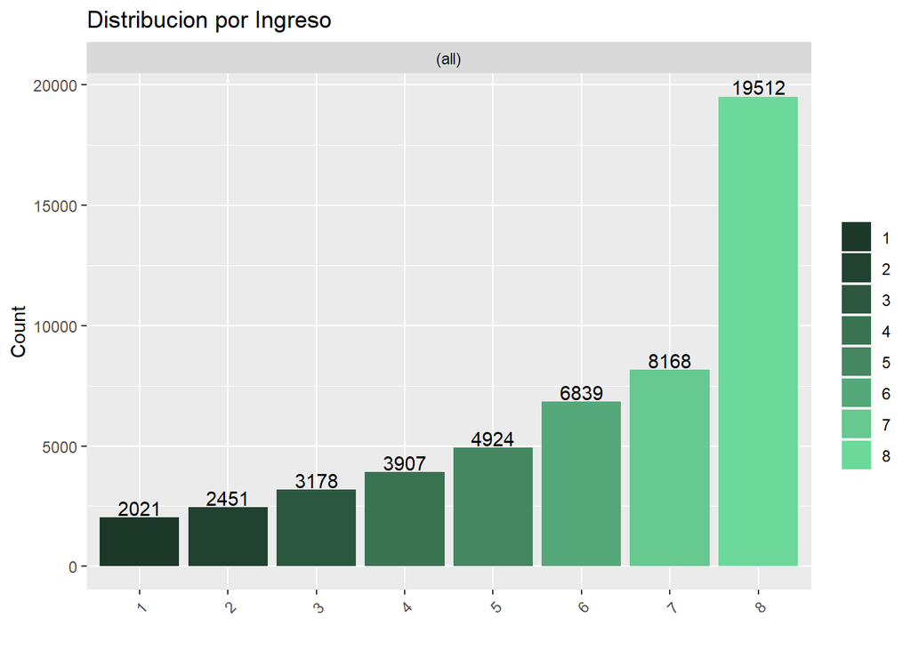

# **Exploratorio:**

## **Estructura del dataset:**

```
## tibble [51,000 × 15] (S3: tbl_df/tbl/data.frame)
##  $ HeartDiseaseorAttack: Factor w/ 2 levels "0","1": 1 1 1 1 1 1 1 1 2 1 ...
##  $ HighBP              : Factor w/ 2 levels "0","1": 2 1 2 2 2 2 2 2 2 1 ...
##  $ HighChol            : Factor w/ 2 levels "0","1": 2 1 2 1 2 2 1 2 2 1 ...
##  $ BMI                 : num [1:51000] 40 25 28 27 24 25 30 25 30 24 ...
##  $ Smoker              : Factor w/ 2 levels "0","1": 2 2 1 1 1 2 2 2 2 1 ...
##  $ Stroke              : Factor w/ 2 levels "0","1": 1 1 1 1 1 1 1 1 1 1 ...
##  $ Diabetes            : Factor w/ 3 levels "0","1","2": 1 1 1 1 1 1 1 1 3 1 ...
##  $ PhysActivity        : Factor w/ 2 levels "0","1": 1 2 1 2 2 2 1 2 1 1 ...
##  $ Fruits              : Factor w/ 2 levels "0","1": 1 1 2 2 2 2 1 1 2 1 ...
##  $ Veggies             : Factor w/ 2 levels "0","1": 2 1 1 2 2 2 1 2 2 2 ...
##  $ HvyAlcoholConsump   : Factor w/ 2 levels "0","1": 1 1 1 1 1 1 1 1 1 1 ...
##  $ Sex                 : Factor w/ 2 levels "0","1": 1 1 1 1 1 2 1 1 1 2 ...
##  $ Age                 : Factor w/ 13 levels "1","2","3","4",..: 9 7 9 11 11 10 9 11 9 8 ...
##  $ Education           : Factor w/ 6 levels "1","2","3","4",..: 4 6 4 3 5 6 6 4 5 4 ...
##  $ Income              : Factor w/ 8 levels "1","2","3","4",..: 3 1 8 6 4 8 7 4 1 3 ...
```

## **Descriptivo de las variables del dataset a utilizar:**

### **Summary:**

```
##  HeartDiseaseorAttack HighBP    HighChol       BMI        Smoker    Stroke
##  0:46426              0:29435   0:29480   Min.   :12.00   0:28325   0:48856
##  1: 4574              1:21565   1:21520   1st Qu.:24.00   1:22675   1: 2144
##                                           Median :27.00
##                                           Mean   :27.85
##                                           3rd Qu.:31.00
##                                           Max.   :96.00
##
##  Diabetes  PhysActivity Fruits    Veggies   HvyAlcoholConsump Sex
##  0:42918   0:11418      0:18062   0: 9038   0:47912           0:28564
##  1: 1077   1:39582      1:32938   1:41962   1: 3088           1:22436
##  2: 7005
##
##
##
##
##       Age        Education     Income
##  10     : 6659   1:   38   8      :19512
##  9      : 6447   2: 1019   7      : 8168
##  8      : 5891   3: 1987   6      : 6839
##  7      : 5152   4:11085   5      : 4924
##  11     : 4958   5:13684   4      : 3907
##  6      : 3856   6:23187   3      : 3178
##  (Other):18037             (Other): 4472
```

En el análisis descriptivo de nuestro conjunto de datos, observamos que alrededor del 9% de las 51,000 personas han experimentado un ataque cardíaco o tienen enfermedades cardíacas (variable “Heartdiseaseorattack”). Al explorar las variables predictoras, notamos patrones interesantes. La presión arterial alta (highbp) está presente en el 42% de los individuos, y el colesterol alto (highchol) en una proporción similar. Además, alrededor del 44% de la población se identifica como fumadora (smoker).

En el caso de la diabetes (diabetes), la mayoría de las personas (85%) no tienen esta condición, pero dentro de los que la tienen, se divide entre diabetes tipo 1 (2%) y tipo 2 (14%).

### **Analisis del BMI por separado:**

```
##    Min. 1st Qu.  Median    Mean 3rd Qu.    Max.
##   12.00   24.00   27.00   27.85   31.00   96.00
```

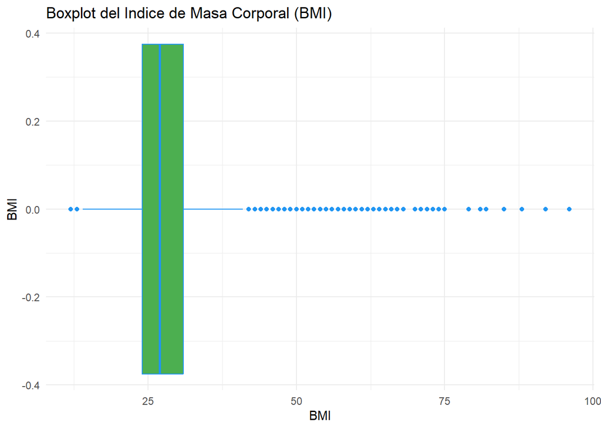

El resumen estadístico del Índice de Masa Corporal **(BMI)** revela información valiosa sobre la distribución de los datos. El BMI promedio es de aproximadamente 27.85, lo cual sugiere que, en promedio, la población tiende a tener un peso superior al considerado “normal” según los estándares de BMI. El rango de valores oscila entre 12 y 96, indicando una variabilidad significativa en los datos. Este amplio rango refleja diferencias sustanciales en los niveles de masa corporal entre los individuos estudiados.

La mediana del BMI se sitúa en 27, señalando que el 50% de la población tiene un BMI inferior a este valor. Por otro lado, el valor máximo de 96 indica la presencia de datos atípicos o valores extremos que pueden afectar la interpretación general. En cuanto al mínimo de 12, sugiere la existencia de casos con bajo peso significativo.

Es importante destacar que, aunque el promedio y la mediana proporcionan una visión central de los datos, la variabilidad en el rango y los valores extremos resalta la diversidad en la composición corporal de la población. Esta variabilidad puede deberse a factores como diferencias en la constitución física, hábitos alimenticios y niveles de actividad física.

## **Analisis de las Relaciones entre las variables expuestas en el data set con las variable dependiente (HeartDiseaseorAttack) :**

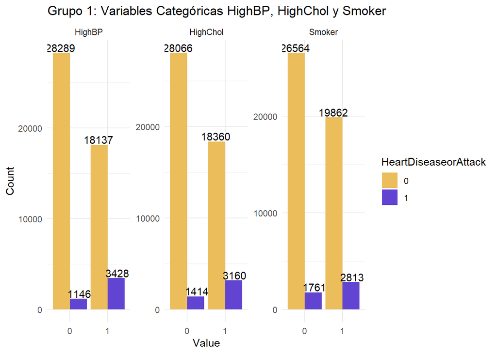

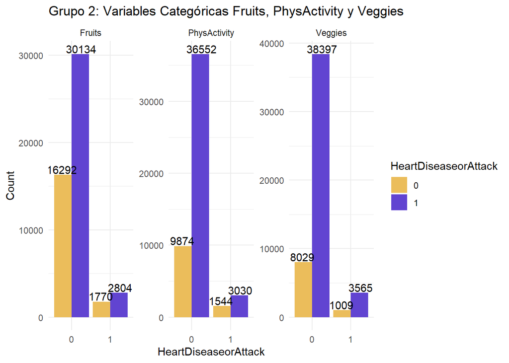

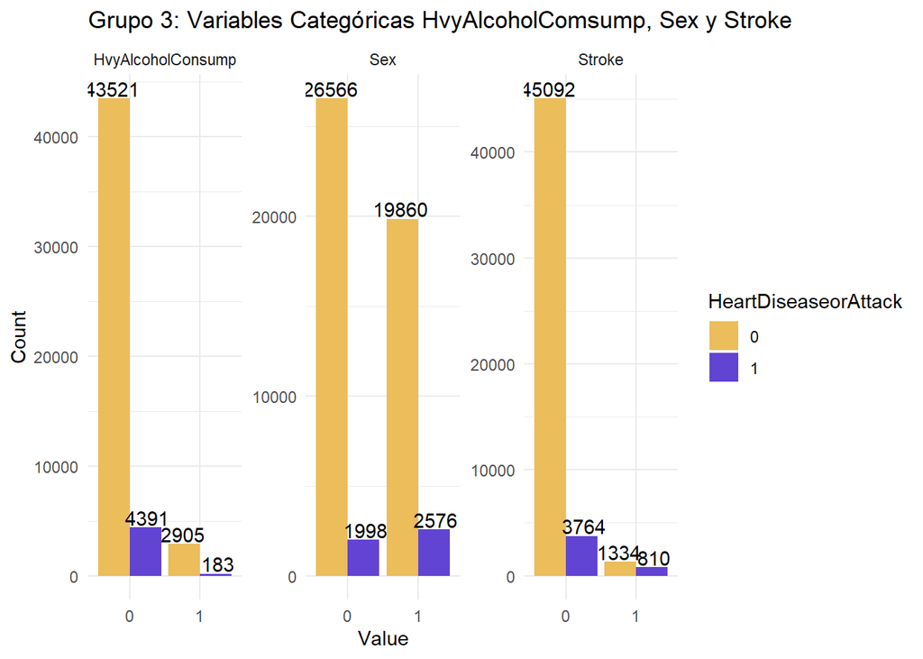

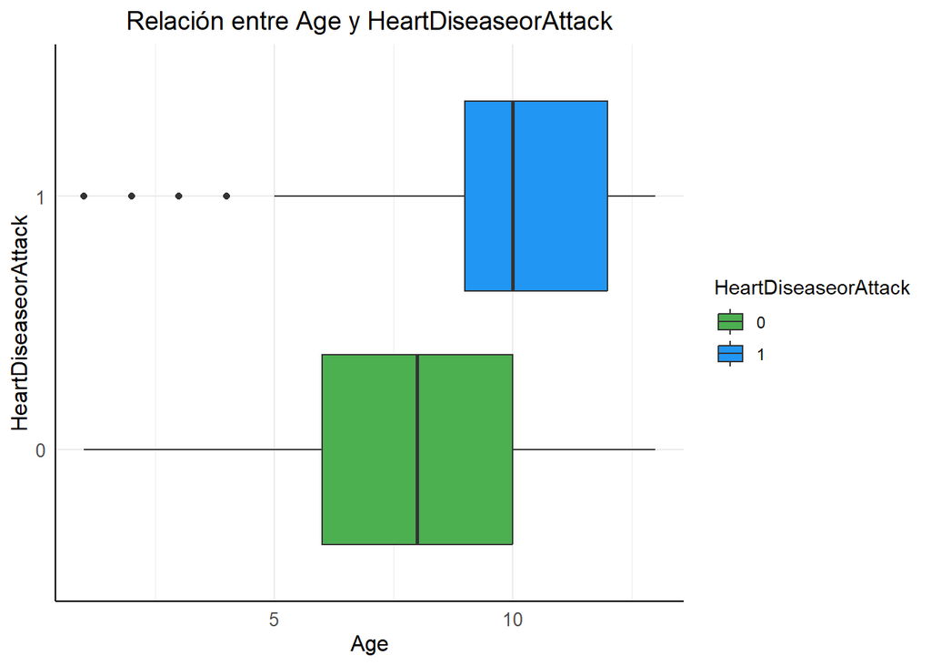

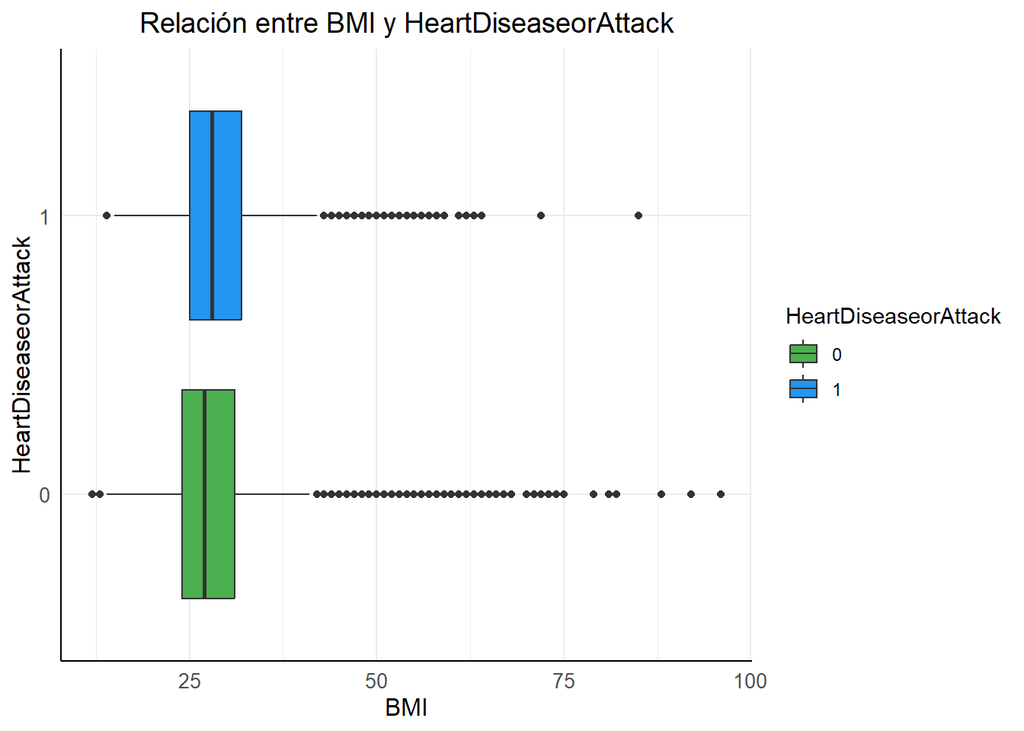

**Variables:** Se han creado dos tipos de gráficos para analizar distintos tipos de variables: uno de barras y otro de caja y bigotes. Los gráficos de barras se dividen en tres grupos:

**Grupo 1:** HighBP, HighChol, Smoker

**Grupo 2:** PhysActivity, Fruits, Veggies

A diferencia del Grupo 1, aquí la concentración es mayor en el color morado (SI) para variables relacionadas con actividad física, consumo de frutas y dieta vegana. Se destaca que, incluso en casos sin ataque cardíaco, hay una proporción considerable de personas que siguen hábitos saludables.

**Grupo 3:** HvyAlcoholConsump, Sex, Stroke

Mayor concentración en el color amarillo (NO) indica una prevalencia de respuestas negativas en cuanto al consumo excesivo de alcohol, género y accidente cerebrovascular. Se observa una proporción significativa de hombres en la muestra, y en términos de ataque cardíaco, las diferencias no son tan marcadas. Gráficos de Caja y Bigotes: Edad y BMI

La presencia de datos atípicos en la distribución de edades en el grupo con ataques cardíacos puede indicar una mayor variabilidad en las edades de este grupo.

**BMI:** En el gráfico de caja y bigotes correspondiente al Índice de Masa Corporal (BMI), se observa una notable similitud entre las dos distribuciones. Ambas muestran la presencia de datos atípicos y tienden a superponerse una sobre la otra. En relación con las cajas, se destaca que, en el caso de la ausencia de ataque cardíaco, los datos atípicos son ligeramente más pronunciados en comparación con aquellos que sí experimentan un ataque cardíaco. Este hallazgo sugiere una mayor variabilidad en los valores de BMI entre las personas sin ataques cardíacos, pero la similitud general entre las distribuciones indica que el BMI no presenta diferencias significativas entre ambos grupos.

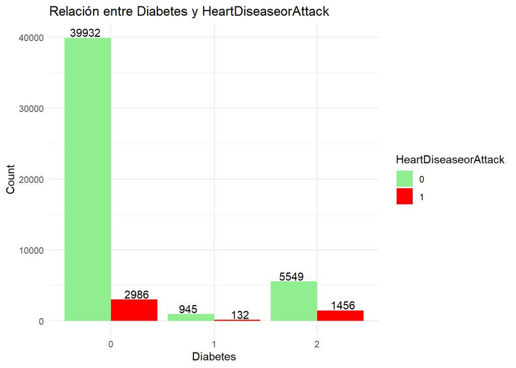

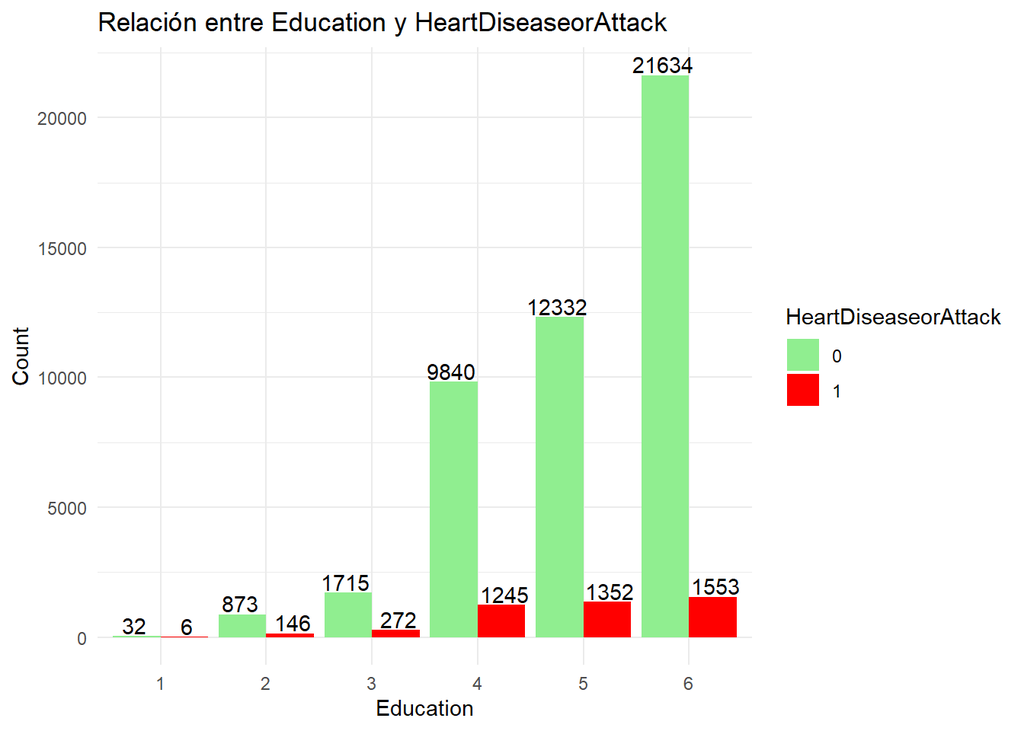

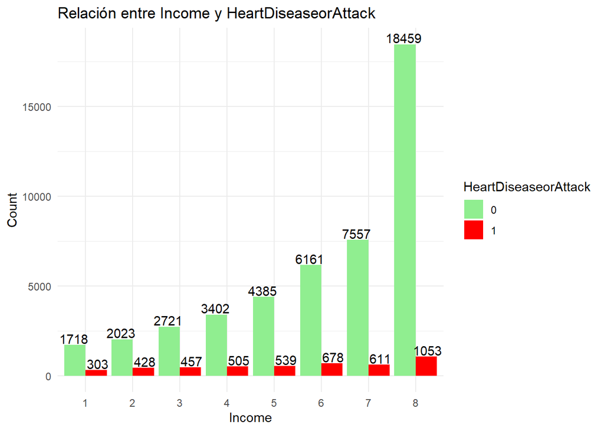

Se han generado nuevas gráficas para explorar la relación entre ataques cardíacos y las variables de educación, ingresos y diabetes.

# **Lanzamiento del modelo con regresión logistica:**

## **Modelo Completo:**

El siguiente modelo incluye todas la variables que pueden predecir (Incluidas aquellas que han sido usadas para la caracterizacion de la poblacion) **HeartDiseaseorAttack**.

```
##
## Call:
## glm(formula = HeartDiseaseorAttack ~ BMI + Age + HighBP + HighChol +
##     Smoker + Stroke + Diabetes + PhysActivity + Fruits + Veggies +
##     Education + Income + Sex + HvyAlcoholConsump, family = binomial(link = "logit"),
##     data = dfcopy)
##
## Coefficients:
##                     Estimate Std. Error z value Pr(>|z|)
## (Intercept)        -5.116051   0.605924  -8.443  < 2e-16 ***
## BMI                 0.015858   0.002861   5.543 2.98e-08 ***
## Age2                0.048822   0.417361   0.117 0.906878
## Age3                0.082406   0.385034   0.214 0.830530
## Age4                0.517876   0.352814   1.468 0.142147
## Age5                0.506563   0.346921   1.460 0.144244
## Age6                1.107619   0.331222   3.344 0.000826 ***
## Age7                1.307304   0.326047   4.010 6.08e-05 ***
## Age8                1.463480   0.324314   4.513 6.41e-06 ***
## Age9                1.761293   0.322984   5.453 4.95e-08 ***
## Age10               1.978962   0.322506   6.136 8.45e-10 ***
## Age11               2.182271   0.322901   6.758 1.40e-11 ***
## Age12               2.354391   0.323744   7.272 3.53e-13 ***
## Age13               2.704068   0.322968   8.373  < 2e-16 ***
## HighBP1             0.682998   0.039748  17.183  < 2e-16 ***
## HighChol1           0.637522   0.036560  17.438  < 2e-16 ***
## Smoker1             0.404508   0.035061  11.537  < 2e-16 ***
## Stroke1             1.304055   0.052414  24.880  < 2e-16 ***
## Diabetes1           0.075440   0.101403   0.744 0.456902
## Diabetes2           0.431368   0.040241  10.720  < 2e-16 ***
## PhysActivity1      -0.197126   0.038002  -5.187 2.13e-07 ***
## Fruits1            -0.030891   0.036451  -0.847 0.396748
## Veggies1            0.062414   0.043292   1.442 0.149394
## Education2         -0.218234   0.514007  -0.425 0.671148
## Education3         -0.260123   0.509646  -0.510 0.609772
## Education4         -0.199679   0.506049  -0.395 0.693149
## Education5         -0.108077   0.506209  -0.214 0.830935
## Education6         -0.256227   0.506524  -0.506 0.612959
## Income2            -0.112760   0.090594  -1.245 0.213251
## Income3            -0.316516   0.088793  -3.565 0.000364 ***
## Income4            -0.373374   0.087347  -4.275 1.91e-05 ***
## Income5            -0.556036   0.086605  -6.420 1.36e-10 ***
## Income6            -0.605614   0.084284  -7.185 6.70e-13 ***
## Income7            -0.796527   0.085687  -9.296  < 2e-16 ***
## Income8            -0.859149   0.082473 -10.417  < 2e-16 ***
## Sex1                0.691499   0.035484  19.488  < 2e-16 ***
## HvyAlcoholConsump1 -0.280747   0.083550  -3.360 0.000779 ***
## ---
## Signif. codes:  0 '***' 0.001 '**' 0.01 '*' 0.05 '.' 0.1 ' ' 1
##
## (Dispersion parameter for binomial family taken to be 1)
##
##     Null deviance: 30785  on 50999  degrees of freedom
## Residual deviance: 24766  on 50963  degrees of freedom
## AIC: 24840
##
## Number of Fisher Scoring iterations: 7
```

```
## [1] 24839.94
```

### **Interpretacion Modelo completo:**

El modelo de regresión logística ajustado tiene la siguiente forma:
$$\begin{align*}
log(odds)=−5.116051+0.015858×BMI+Age_2+Age_3+…+HvyAlcoholConsump_1
\end{align*}$$

A continuación, se proporciona una interpretación de algunos de los coeficientes clave en el modelo:

**BMI (Índice de Masa Corporal):** El coeficiente asociado a BMI es **0.015858**, lo que significa que un aumento de una unidad en BMI se asocia con un aumento de aproximadamente **0.015858** en el logaritmo de odds de experimentar un ataque cardíaco, manteniendo todas las demás variables constantes.

**Edad (Age):** Las variables Age están codificadas de manera categórica. Por ejemplo, Age2, Age3, etc. Cada una de estas variables representa el efecto de esa categoría específica de edad en comparación con la categoría de referencia (que no está explícitamente indicada en el resumen del modelo). Por ejemplo, Age2 representa el efecto de estar en el grupo de edad 2 en comparación con la referencia.

**HighBP (Presión Arterial Alta), HighChol (Colesterol Alto), Smoker (Fumador), Stroke (Accidente Cerebrovascular), Diabetes (Diabetes):** Todas estas variables tienen coeficientes positivos, lo que indica que tener estos factores de riesgo aumenta el logaritmo de odds de experimentar un ataque cardíaco en comparación con no tenerlos.

**Fruits (Consumo de Frutas), Veggies (Consumo de Vegetales):** Estos coeficientes no son estadísticamente significativos (
$$p>0.05$$
) lo que sugiere que su contribución al modelo no es significativa.

**Education (Educación), Income (Ingresos), Sex (Género), HvyAlcoholConsump (Consumo Pesado de Alcohol):** Cada uno de estos coeficientes representa el efecto de esa categoría específica en comparación con la categoría de referencia.

## **Modelo final:**

```
## Start:  AIC=24839.94
## HeartDiseaseorAttack ~ BMI + Age + HighBP + HighChol + Smoker +
##     Stroke + Diabetes + PhysActivity + Fruits + Veggies + Education +
##     Income + Sex + HvyAlcoholConsump
##
##                     Df Deviance   AIC
## - Fruits             1    24767 24839
## <none>                    24766 24840
## - Veggies            1    24768 24840
## - Education          5    24779 24843
## - HvyAlcoholConsump  1    24778 24850
## - PhysActivity       1    24793 24865
## - BMI                1    24796 24868
## - Diabetes           2    24878 24948
## - Smoker             1    24901 24973
## - Income             7    24955 25015
## - HighBP             1    25074 25146
## - HighChol           1    25081 25153
## - Sex                1    25153 25225
## - Stroke             1    25335 25407
## - Age               12    25846 25896
##
## Step:  AIC=24838.66
## HeartDiseaseorAttack ~ BMI + Age + HighBP + HighChol + Smoker +
##     Stroke + Diabetes + PhysActivity + Veggies + Education +
##     Income + Sex + HvyAlcoholConsump
##
##                     Df Deviance   AIC
## - Veggies            1    24768 24838
## <none>                    24767 24839
## - Education          5    24780 24842
## - HvyAlcoholConsump  1    24779 24849
## - PhysActivity       1    24794 24864
## - BMI                1    24797 24867
## - Diabetes           2    24879 24947
## - Smoker             1    24902 24972
## - Income             7    24956 25014
## - HighBP             1    25076 25146
## - HighChol           1    25082 25152
## - Sex                1    25158 25228
## - Stroke             1    25336 25406
## - Age               12    25851 25899
##
## Step:  AIC=24838.33
## HeartDiseaseorAttack ~ BMI + Age + HighBP + HighChol + Smoker +
##     Stroke + Diabetes + PhysActivity + Education + Income + Sex +
##     HvyAlcoholConsump
##
##                     Df Deviance   AIC
## <none>                    24768 24838
## - Education          5    24781 24841
## - HvyAlcoholConsump  1    24780 24848
## - PhysActivity       1    24795 24863
## - BMI                1    24799 24867
## - Diabetes           2    24880 24946
## - Smoker             1    24904 24972
## - Income             7    24956 25012
## - HighBP             1    25077 25145
## - HighChol           1    25084 25152
## - Sex                1    25158 25226
## - Stroke             1    25336 25404
## - Age               12    25855 25901
```

```
##
## Call:
## glm(formula = HeartDiseaseorAttack ~ BMI + Age + HighBP + HighChol +
##     Smoker + Stroke + Diabetes + PhysActivity + Education + Income +
##     Sex + HvyAlcoholConsump, family = binomial(link = "logit"),
##     data = dfcopy)
##
## Coefficients:
##                    Estimate Std. Error z value Pr(>|z|)
## (Intercept)        -5.09816    0.60412  -8.439  < 2e-16 ***
## BMI                 0.01590    0.00286   5.560 2.69e-08 ***
## Age2                0.04876    0.41736   0.117 0.906998
## Age3                0.08241    0.38503   0.214 0.830512
## Age4                0.51606    0.35282   1.463 0.143561
## Age5                0.50663    0.34692   1.460 0.144192
## Age6                1.10716    0.33122   3.343 0.000830 ***
## Age7                1.30639    0.32605   4.007 6.16e-05 ***
## Age8                1.46321    0.32431   4.512 6.43e-06 ***
## Age9                1.75937    0.32298   5.447 5.11e-08 ***
## Age10               1.97629    0.32250   6.128 8.90e-10 ***
## Age11               2.18025    0.32289   6.752 1.45e-11 ***
## Age12               2.35220    0.32371   7.266 3.70e-13 ***
## Age13               2.69997    0.32289   8.362  < 2e-16 ***
## HighBP1             0.68280    0.03974  17.181  < 2e-16 ***
## HighChol1           0.63799    0.03654  17.458  < 2e-16 ***
## Smoker1             0.40604    0.03503  11.590  < 2e-16 ***
## Stroke1             1.30266    0.05240  24.860  < 2e-16 ***
## Diabetes1           0.07519    0.10140   0.741 0.458419
## Diabetes2           0.43097    0.04023  10.711  < 2e-16 ***
## PhysActivity1      -0.19528    0.03764  -5.189 2.12e-07 ***
## Education2         -0.21449    0.51299  -0.418 0.675866
## Education3         -0.25723    0.50862  -0.506 0.613030
## Education4         -0.19508    0.50502  -0.386 0.699289
## Education5         -0.10110    0.50519  -0.200 0.841383
## Education6         -0.24895    0.50551  -0.492 0.622387
## Income2            -0.11071    0.09058  -1.222 0.221634
## Income3            -0.31426    0.08877  -3.540 0.000400 ***
## Income4            -0.36960    0.08730  -4.234 2.30e-05 ***
## Income5            -0.55070    0.08652  -6.365 1.95e-10 ***
## Income6            -0.59901    0.08413  -7.120 1.08e-12 ***
## Income7            -0.79015    0.08553  -9.238  < 2e-16 ***
## Income8            -0.85098    0.08223 -10.349  < 2e-16 ***
## Sex1                0.68982    0.03528  19.552  < 2e-16 ***
## HvyAlcoholConsump1 -0.27661    0.08348  -3.313 0.000922 ***
## ---
## Signif. codes:  0 '***' 0.001 '**' 0.01 '*' 0.05 '.' 0.1 ' ' 1
##
## (Dispersion parameter for binomial family taken to be 1)
##
##     Null deviance: 30785  on 50999  degrees of freedom
## Residual deviance: 24768  on 50965  degrees of freedom
## AIC: 24838
##
## Number of Fisher Scoring iterations: 7
```

```
##        (Intercept)                BMI               Age2               Age3
##        -5.09815852         0.01590202         0.04875849         0.08241323
##               Age4               Age5               Age6               Age7
##         0.51606058         0.50662610         1.10715966         1.30638658
##               Age8               Age9              Age10              Age11
##         1.46320768         1.75937206         1.97629525         2.18024793
##              Age12              Age13            HighBP1          HighChol1
##         2.35220280         2.69997211         0.68280460         0.63798501
##            Smoker1            Stroke1          Diabetes1          Diabetes2
##         0.40604046         1.30265836         0.07518454         0.43096779
##      PhysActivity1         Education2         Education3         Education4
##        -0.19528196        -0.21448532        -0.25723331        -0.19507954
##         Education5         Education6            Income2            Income3
##        -0.10110042        -0.24894965        -0.11071148        -0.31425906
##            Income4            Income5            Income6            Income7
##        -0.36960329        -0.55069729        -0.59900884        -0.79015015
##            Income8               Sex1 HvyAlcoholConsump1
##        -0.85098276         0.68981892        -0.27660871
```

```
##                          2.5 %      97.5 %
## (Intercept)        -6.36019586 -3.97415785
## BMI                 0.01027477  0.02148594
## Age2               -0.76205001  0.89620992
## Age3               -0.64645896  0.88083527
## Age4               -0.13341105  1.26479359
## Age5               -0.12849914  1.24615124
## Age6                0.50974764  1.82201565
## Age7                0.72129251  2.01305073
## Age8                0.88223353  2.16712105
## Age9                1.18155945  2.46117040
## Age10               1.39962362  2.67733215
## Age11               1.60266084  2.88190387
## Age12               1.77266379  3.05517708
## Age13               2.12238138  3.40163882
## HighBP1             0.60514675  0.76094125
## HighChol1           0.56652951  0.70978823
## Smoker1             0.33745797  0.47479543
## Stroke1             1.19971971  1.40514718
## Diabetes1          -0.12737258  0.27038761
## Diabetes2           0.35193305  0.50965653
## PhysActivity1      -0.26887336 -0.12133181
## Education2         -1.16115362  0.87568154
## Education3         -1.19415087  0.82578685
## Education4         -1.12392966  0.88211653
## Education5         -1.03028763  0.97638709
## Education6         -1.17885203  0.82907843
## Income2            -0.28787069  0.06730180
## Income3            -0.48778864 -0.13973363
## Income4            -0.54013981 -0.19784914
## Income5            -0.71966355 -0.38042651
## Income6            -0.76311305 -0.43324186
## Income7            -0.95706684 -0.62169746
## Income8            -1.01113790 -0.68874345
## Sex1                0.62076520  0.75907041
## HvyAlcoholConsump1 -0.44313513 -0.11571553
```

```
## [1] 24838.33
```

El modelo final fue desarrollado para prever la probabilidad de enfermedad cardíaca o ataques cardíacos, utilizando variables como índice de masa corporal (BMI), edad, presión arterial alta (HighBP), consumo de alcohol, ingresos, género y otros factores. Los coeficientes indican cómo cada variable afecta las log-odds de la enfermedad cardíaca. Por ejemplo, un incremento en el BMI se asocia con un aumento en las log-odds, mientras que el consumo pesado de alcohol está relacionado con una disminución. La variable Income3 indica que las personas en ese nivel de ingresos tienen log-odds más bajas. El género masculino (Sex1) está asociado con log-odds más altas. El AIC del modelo es 24838, indicando un buen ajuste, y las devianzas nula y residual también respaldan la calidad del ajuste del modelo en comparación con un modelo nulo.

**Intercepto (Intercepto):** El intercepto es -5.09816. En el contexto de la regresión logística, el intercepto representa el logaritmo de la razón de odds (log-odds) de tener enfermedad cardíaca cuando todas las demás variables predictoras son cero. Sin embargo, es importante tener en cuenta que en este caso, las variables como BMI y Age raramente tomarán valores nulos en la realidad, lo que limita la interpretación directa del intercepto en términos prácticos.

Coeficientes de las Variables Predictoras:

**BMI (Índice de Masa Corporal):** Un aumento de una unidad en el índice de masa corporal (BMI) está asociado con un aumento de aproximadamente 0.0159 en el logaritmo de las odds de tener enfermedad cardíaca, manteniendo constantes las demás variables.

**HighBP1 (Presión Arterial Alta):** La presencia de alta presión sanguínea (HighBP1) está asociada con un aumento de 0.68280 en el logaritmo de las odds de tener enfermedad cardíaca.

**HighChol1 (Niveles altos de colesterol):** Tener niveles altos de colesterol (HighChol1) está asociado con un aumento de 0.63799 en el logaritmo de las odds de tener enfermedad cardíaca. Esto indica que las personas con niveles altos de colesterol tienen mayores odds de desarrollar enfermedad cardíaca en comparación con aquellas con niveles normales, manteniendo constantes las demás variables en el modelo.

**Smoker1 (Fumador):** Ser fumador (Smoker1) está asociado con un aumento de 0.40604 en el logaritmo de las odds de tener enfermedad cardíaca. Esto indica que los fumadores tienen mayores odds de desarrollar enfermedad cardíaca en comparación con los no fumadores, manteniendo constantes las demás variables en el modelo.

**HvyAlcoholConsump1 (Consumo Pesado de Alcohol):** El consumo pesado de alcohol (HvyAlcoholConsump1) está asociado con una disminución de 0.27661 en el logaritmo de las odds de tener enfermedad cardíaca.

**Ingresos (Income):** Cada nivel de ingresos tiene un efecto diferente en las odds de tener enfermedad cardíaca. Por ejemplo, Income3 tiene un coeficiente de -0.31426, lo que sugiere que las personas en Income3 tienen una odds e^(-0.31426) veces menor de tener enfermedad cardíaca en comparación con la categoría de referencia.

**Stroke1 (Accidente Cerebrovascular):** Haber tenido un accidente cerebrovascular (Stroke1) está asociado con un aumento significativo de 1.30266 en el logaritmo de las odds de tener enfermedad cardíaca.

**Diabetes1 y Diabetes2 (Diabetes):** Tener diabetes tiene un efecto positivo en las odds de tener enfermedad cardíaca. Diabetes1 tiene un coeficiente de 0.07519, y Diabetes2 tiene un coeficiente de 0.43097. * **PhysActivity1 (Actividad Física):** La participación en actividad física (PhysActivity1) está asociada con una disminución de -0.19528 en el logaritmo de las odds de tener enfermedad cardíaca.

**Education2, Education3, Education4, Education5, Education6 (Niveles de Educación):** Los diferentes niveles de educación tienen efectos variables en las odds de tener enfermedad cardíaca en comparación con la categoría de referencia.

**Parámetro de dispersión para la familia binomial tomado como 1:** Este parámetro refleja la varianza de la distribución binomial. En el contexto de un modelo de regresión logística, se asume que la varianza de los errores sigue una distribución binomial, y este parámetro indica que se ha utilizado una varianza de 1 en el modelo.

**Devianza nula (Null deviance):** La devianza nula es una medida de cuán bien se ajusta el modelo nulo, que es el modelo que no incluye ninguna variable explicativa (solo el intercepto). La devianza nula compara la bondad de ajuste del modelo nulo con la bondad de ajuste del modelo completo. En este caso, la devianza nula es 30785.

**Devianza residual (Residual deviance):** La devianza residual es una medida de cuán bien se ajusta el modelo completo después de incluir las variables explicativas. En este caso, la devianza residual es 24768. Una devianza residual menor indica un mejor ajuste del modelo a los datos.

**AIC (Criterio de Información de Akaike):** El AIC es un criterio de selección de modelos que penaliza la complejidad del modelo. Cuanto menor sea el AIC, mejor. En este caso, el AIC es 24838, y se utiliza para comparar modelos alternativos. En comparación con otros modelos, aquellos con AIC más bajo se consideran preferibles.

**Número de iteraciones de Fisher Scoring:** Este valor (7 en este caso) indica cuántas veces se realizaron las iteraciones de Fisher Scoring para estimar los parámetros del modelo. Más iteraciones pueden ser necesarias para converger hacia los valores finales de los coeficientes. En este caso, se realizaron 7 iteraciones.

### **Grafico del modelo:**

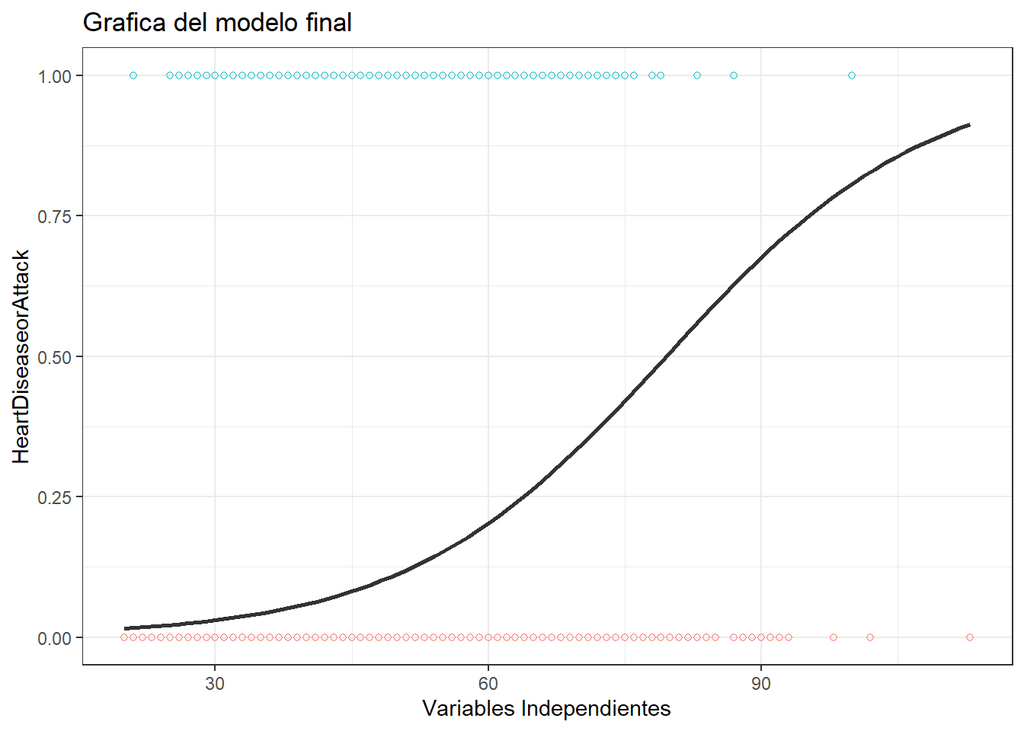

```
## Profiled confidence intervals may take longer time to compute.
##   Use `ci_method="wald"` for faster computation of CIs.
```

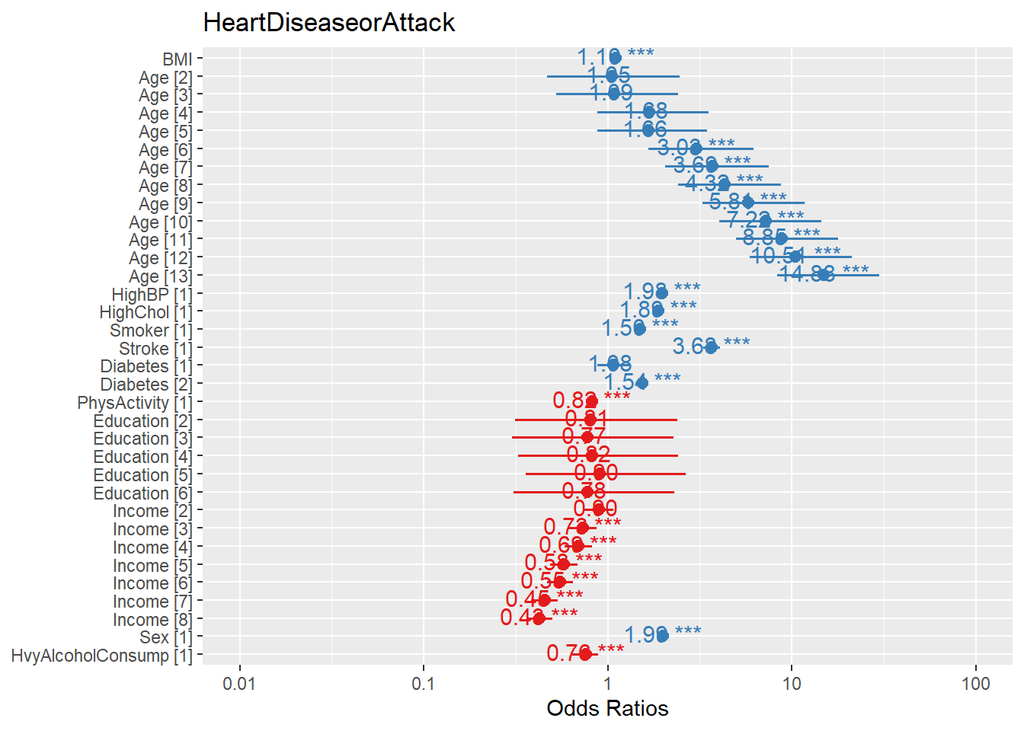

### **Grafico del log_ODDs:**

[figure not shown]

Un aspecto adicional a considerar es que nuestro intercepto es el más negativo, indicando que la suma ponderada de nuestras variables predictoras contribuye a un valor negativo en la variable de respuesta.

### **Supuestos en los residuos:**

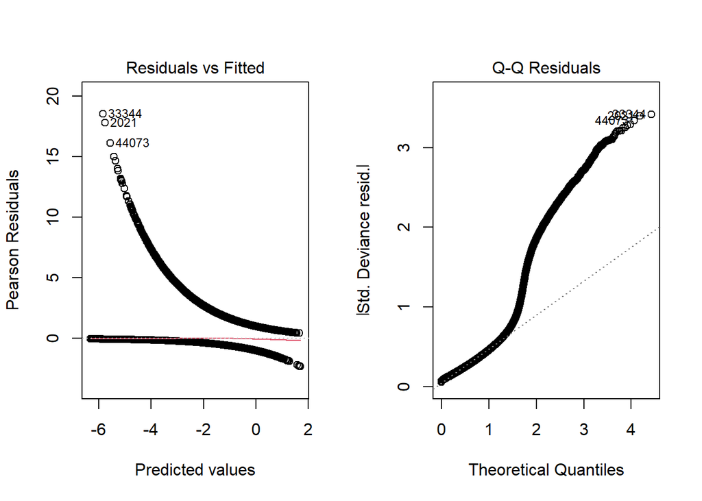

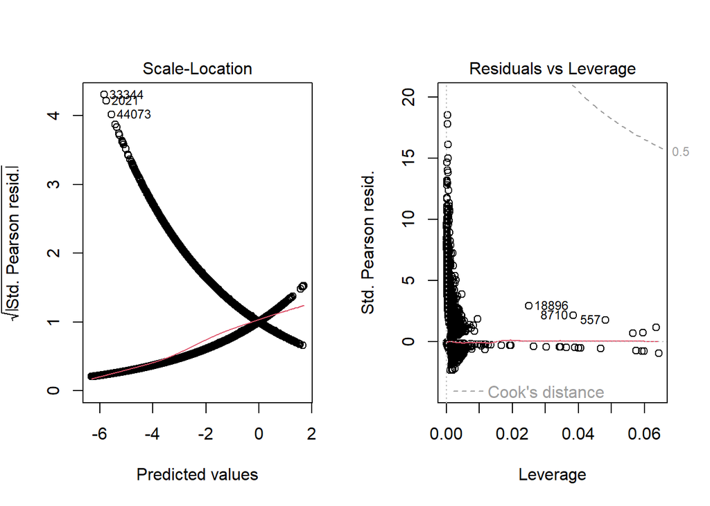

```r
# Establecer el diseño de la ventana gráfica
par(mfrow = c(1, 2))

# Graficar las cuatro gráficas
plot(modeloFinal)
```

# **Conclusiones:**

Este estudio por medio del análisis de regresión logística en el conjunto de datos **heart_disease_health_indicators_BRFSS2015** proporciona información esencial sobre la relación entre diversas variables y la probabilidad de padecer enfermedad cardíaca. En particular, el modelo final ajustado revela coeficientes significativos para varios factores de riesgo. Por ejemplo, el índice de masa corporal (BMI) y la edad presentan asociaciones positivas, indicando que un aumento en el BMI y el envejecimiento se relacionan con un incremento en la probabilidad de enfermedad cardíaca. Factores clásicos como la presión arterial alta (HighBP), niveles elevados de colesterol (HighChol) y el hábito de fumar (Smoker) también destacan como elementos de riesgo, al igual que antecedentes de accidente cerebrovascular (Stroke) y la presencia de diabetes.

Este análisis integral ofrece una comprensión detallada de cómo diversas variables contribuyen a la predicción de enfermedades cardíacas en esta población específica. Las asociaciones identificadas son consistentes con la literatura médica y proporcionan una base sólida para comprender los factores de riesgo cardiovascular. **Sin embargo, es crucial reconocer que, aunque el modelo es informativo y respaldado por métricas de ajuste sólidas, la aplicación clínica debe considerar la complejidad de los casos individuales y la necesidad de validación en conjuntos de datos externos.**

# **Bibliografia:**

**1.** Joaquin_AR. (2016). **Introducción a la Regresión Lineal Múltiple.**\ https://rpubs.com/Joaquin_AR/226291

**2.** ebologna. (2023-06-20). **Introducción a RStudio: medidas descriptivas.**\ https://rpubs.com/ebologna/1056389

**3.** Silverberg, J. (2015). **Asociación entre dermatitis atópica en adultos, enfermedades cardiovasculares y aumento de ataques cardíacos en tres estudios poblacionales. National library of medicine.\ https://pubmed.ncbi.nlm.nih.gov/26148129/

**4.** Rico, V. A. (2021). Estadística Descriptiva Básica en R.\ https://www.youtube.com/watch?v=Sn_D6AhMWjY

**5.** **Centers for Disease Control and Prevention. (2015). Codebook de BRFSS 2015.**\ https://www.cdc.gov/brfss/annual_data/2015/pdf/codebook15_llcp.pdf

**6.** Alex Teboul. (2015). **Heart Disease Health Indicators Dataset.**\ https://www.kaggle.com/datasets/alexteboul/heart-disease-health-indicators-dataset/data

**7.** MedlinePlus. (2022). **MedlinePlus - Información de salud.**\ https://medlineplus.gov/spanish/ency/article/000195.htm